# RPC-PI Experiment — Main Figures

2026-07-05

# 1 Objetivo

Este R Markdown gera as **figuras principais** do experimento RPC-PI a partir das tabelas produzidas no `01_descriptive_metrics.Rmd` e, quando necessário, dos arquivos originais em `data/results/`.

As correções incorporadas nesta versão são:

1. cada cenário usa uma cor própria e consistente em todos os gráficos comparativos;
2. os gráficos de barras usam apenas os nomes curtos `C0`, `C1`, `C2`, `C3` e `C4`;
3. os heatmaps usam paletas coloridas em vez de tons de cinza;
4. foi adicionada uma figura **radial** inspirada no exemplo enviado.

# 2 Caminhos e dados

```r
DATA_DIR <- here::here("data", "results")
DESC_DIR <- here::here("tables", "descriptive")
MAIN_TABLES_DIR <- here::here("tables", "main")
FIG_DIR <- here::here("figures", "main")

fs::dir_create(FIG_DIR)
fs::dir_create(MAIN_TABLES_DIR)

if (!dir.exists(DATA_DIR)) {
  stop(
    "Não encontrei data/results/. Extraia o ZIP primeiro com: ",
    "unzip('results.zip', exdir = 'data')"
  )
}

if (!dir.exists(DESC_DIR)) {
  stop(
    "Não encontrei tables/descriptive/. Rode primeiro o Rmd 01_descriptive_metrics.Rmd."
  )
}
```

# 3 Funções auxiliares

```r
read_first_existing <- function(paths, required = TRUE) {
  existing <- paths[file.exists(paths)]

  if (length(existing) == 0) {
    if (required) {
      stop("Nenhum destes arquivos foi encontrado:\n", paste(paths, collapse = "\n"))
    }
    return(NULL)
  }

  readr::read_csv(existing[[1]], show_col_types = FALSE)
}

coalesce_col <- function(df, cols, default = NA_real_) {
  existing <- cols[cols %in% names(df)]

  if (length(existing) == 0) {
    return(rep(default, nrow(df)))
  }

  out <- df[[existing[[1]]]]
  if (length(existing) > 1) {
    for (nm in existing[-1]) {
      out <- dplyr::coalesce(out, df[[nm]])
    }
  }
  out
}

weighted_rate <- function(rate, weight) {
  valid <- !is.na(rate) & !is.na(weight) & weight > 0
  if (!any(valid)) return(NA_real_)
  sum(rate[valid] * weight[valid]) / sum(weight[valid])
}

safe_sd <- function(x) {
  if (sum(!is.na(x)) <= 1) return(NA_real_)
  sd(x, na.rm = TRUE)
}

scenario_order <- c(
  "c0_base",
  "c1_struq_format_only",
  "c2_struq_sft",
  "c3_secalign_dpo",
  "c4_ih_sft"
)

scenario_short_map <- c(
  c0_base = "C0",
  c1_struq_format_only = "C1",
  c2_struq_sft = "C2",
  c3_secalign_dpo = "C3",
  c4_ih_sft = "C4"
)

scenario_palette <- c(
  C0 = "#7F7F7F", # cinza neutro - baseline
  C1 = "#D55E00", # laranja/vermelho - format-only
  C2 = "#0072B2", # azul - StruQ-like SFT
  C3 = "#CC79A7", # magenta/roxo - DPO
  C4 = "#009E73"  # verde - Instruction-Hierarchy-like SFT
)

sort_scenarios <- function(df) {
  df |>
    mutate(scenario_id = factor(scenario_id, levels = scenario_order)) |>
    arrange(scenario_id) |>
    mutate(scenario_id = as.character(scenario_id))
}

make_scenario_short <- function(scenario_id) {
  out <- unname(scenario_short_map[scenario_id])
  ifelse(is.na(out), scenario_id, out)
}

ordered_scenario_short <- function(x) {
  factor(x, levels = c("C0", "C1", "C2", "C3", "C4"))
}

add_scenario_info <- function(df) {
  joined <- df |>
    left_join(scenario_lookup, by = "scenario_id", suffix = c("", "_lookup"))

  if (!("scenario_label" %in% names(joined))) {
    joined$scenario_label <- joined$scenario_id
  }

  if ("scenario_label_lookup" %in% names(joined)) {
    joined <- joined |>
      mutate(
        scenario_label = coalesce(
          as.character(scenario_label),
          as.character(scenario_label_lookup)
        )
      )
  }

  if (!("scenario_short" %in% names(joined))) {
    joined$scenario_short <- make_scenario_short(joined$scenario_id)
  }

  if ("scenario_short_lookup" %in% names(joined)) {
    joined <- joined |>
      mutate(
        scenario_short = coalesce(
          as.character(scenario_short),
          as.character(scenario_short_lookup)
        )
      )
  }

  joined |>
    select(-any_of(c("scenario_label_lookup", "scenario_short_lookup")))
}

figure_index <- tibble(
  figure = character(),
  file = character(),
  description = character()
)

record_figure <- function(filename, title, description) {
  figure_index <<- bind_rows(
    figure_index,
    tibble(
      figure = title,
      file = file.path("figures", "main", filename),
      description = description
    )
  )
  invisible(NULL)
}

save_figure <- function(plot, filename, title, description, width = 10, height = 6) {
  ggsave(
    filename = file.path(FIG_DIR, filename),
    plot = plot,
    width = width,
    height = height,
    dpi = 320,
    bg = "white"
  )

  record_figure(filename, title, description)
  invisible(plot)
}

base_theme <- function(base_size = 12) {
  theme_minimal(base_size = base_size) +
    theme(
      legend.position = "bottom",
      plot.title.position = "plot",
      plot.title = element_text(face = "bold"),
      plot.subtitle = element_text(color = "grey30"),
      panel.grid.minor = element_blank(),
      axis.title = element_text(face = "bold")
    )
}

pct_axis <- scales::percent_format(accuracy = 1)
pct_axis_small <- scales::percent_format(accuracy = 0.1)

coolwarm_cols <- c(
  "#3B4CC0",
  "#8DB0FE",
  "#F7F7F7",
  "#F4987A",
  "#B40426"
)
```

# 4 Carregamento e preparação

```r
run_level <- read_first_existing(c(
  file.path(DESC_DIR, "06_run_level_metrics_recomputed.csv"),
  file.path(DATA_DIR, "metrics", "full", "run_level_metrics.csv")
)) |>
  sort_scenarios()

if (!("scenario_label" %in% names(run_level))) {
  run_level <- run_level |>
    mutate(scenario_label = scenario_id)
}

run_level <- run_level |>
  mutate(
    scenario_short = make_scenario_short(scenario_id),
    scenario_short = ordered_scenario_short(scenario_short)
  )

run_level$injection_following_rate_seen <- coalesce_col(
  run_level,
  c("injection_following_rate_seen", "targeted_asr_seen", "attack_success_rate_seen", "binary_asv_seen")
)
run_level$injection_following_rate_unseen <- coalesce_col(
  run_level,
  c("injection_following_rate_unseen", "targeted_asr_unseen", "attack_success_rate_unseen", "binary_asv_unseen")
)
run_level$injection_following_rate_all_attacks <- coalesce_col(
  run_level,
  c("injection_following_rate_all_attacks", "targeted_asr_all_attacks", "attack_success_rate_all_attacks", "binary_asv_all_attacks")
)

run_level$targeted_asr_seen <- coalesce_col(
  run_level,
  c("targeted_asr_seen", "injection_following_rate_seen", "attack_success_rate_seen", "binary_asv_seen")
)
run_level$targeted_asr_unseen <- coalesce_col(
  run_level,
  c("targeted_asr_unseen", "injection_following_rate_unseen", "attack_success_rate_unseen", "binary_asv_unseen")
)
run_level$targeted_asr_all_attacks <- coalesce_col(
  run_level,
  c("targeted_asr_all_attacks", "injection_following_rate_all_attacks", "attack_success_rate_all_attacks", "binary_asv_all_attacks")
)

scenario_lookup <- run_level |>
  distinct(scenario_id, scenario_label, scenario_short)

scenario_summary <- run_level |>
  group_by(scenario_id, scenario_label, scenario_short) |>
  summarise(
    n_seeds = n_distinct(seed),
    clean_accuracy = mean(clean_accuracy, na.rm = TRUE),
    clean_accuracy_sd = safe_sd(clean_accuracy),
    robust_accuracy_all_attacks = mean(robust_accuracy_all_attacks, na.rm = TRUE),
    robust_accuracy_all_attacks_sd = safe_sd(robust_accuracy_all_attacks),
    targeted_asr_all_attacks = mean(targeted_asr_all_attacks, na.rm = TRUE),
    targeted_asr_all_attacks_sd = safe_sd(targeted_asr_all_attacks),
    injection_following_rate_all_attacks = mean(injection_following_rate_all_attacks, na.rm = TRUE),
    injection_following_rate_all_attacks_sd = safe_sd(injection_following_rate_all_attacks),
    untargeted_asr_all_attacks = mean(untargeted_asr_all_attacks, na.rm = TRUE),
    untargeted_asr_all_attacks_sd = safe_sd(untargeted_asr_all_attacks),
    invalid_output_rate_all_attacks = mean(invalid_output_rate_all_attacks, na.rm = TRUE),
    invalid_output_rate_all_attacks_sd = safe_sd(invalid_output_rate_all_attacks),
    utility_under_attack_all_attacks = mean(utility_under_attack_all_attacks, na.rm = TRUE),
    utility_under_attack_all_attacks_sd = safe_sd(utility_under_attack_all_attacks),
    utility_drop = mean(utility_drop, na.rm = TRUE),
    utility_drop_sd = safe_sd(utility_drop),
    robust_accuracy_seen = mean(robust_accuracy_seen, na.rm = TRUE),
    injection_following_rate_seen = mean(injection_following_rate_seen, na.rm = TRUE),
    robust_accuracy_unseen = mean(robust_accuracy_unseen, na.rm = TRUE),
    injection_following_rate_unseen = mean(injection_following_rate_unseen, na.rm = TRUE),
    .groups = "drop"
  ) |>
  mutate(
    across(where(is.numeric), ~ ifelse(is.nan(.x) | is.infinite(.x), NA_real_, .x)),
    scenario_short = ordered_scenario_short(as.character(scenario_short))
  ) |>
  sort_scenarios()

readr::write_csv(
  scenario_summary,
  file.path(MAIN_TABLES_DIR, "figures_scenario_summary_fraction.csv")
)

scenario_summary |>
  select(
    scenario_short,
    n_seeds,
    clean_accuracy,
    robust_accuracy_all_attacks,
    injection_following_rate_all_attacks,
    invalid_output_rate_all_attacks,
    utility_drop
  ) |>
  mutate(across(where(is.numeric) & !matches("n_seeds"), ~ .x * 100)) |>
  knitr::kable(
    digits = 2,
    caption = "Resumo das métricas usadas nas figuras principais. Valores em porcentagem."
  )
```

Resumo das métricas usadas nas figuras principais. Valores em porcentagem.

| scenario_short | n_seeds | clean_accuracy | robust_accuracy_all_attacks | injection_following_rate_all_attacks | invalid_output_rate_all_attacks | utility_drop |
| --- | --- | --- | --- | --- | --- | --- |
| C0 | 1 | 77.29 | 21.29 | 78.18 | 0.01 | 0.00 |
| C1 | 1 | 77.35 | 20.98 | 78.52 | 0.04 | -0.05 |
| C2 | 3 | 85.70 | 98.37 | 0.43 | 0.00 | -8.40 |
| C3 | 3 | 75.09 | 91.31 | 6.79 | 0.50 | 2.20 |
| C4 | 3 | 85.64 | 98.60 | 0.05 | 0.00 | -8.35 |

# 5 Figura 1 — Clean accuracy vs Injection Following Rate

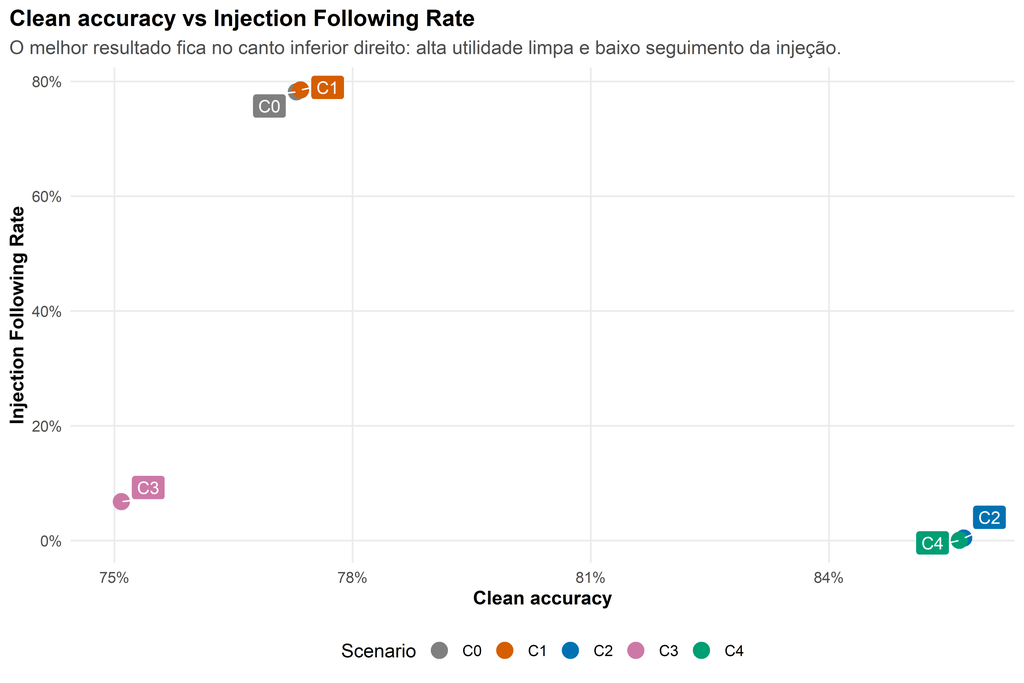

```r
p_clean_vs_ifr <- scenario_summary |>
  ggplot(aes(x = clean_accuracy, y = injection_following_rate_all_attacks, color = scenario_short)) +
  geom_segment(
    aes(
      x = pmax(clean_accuracy - clean_accuracy_sd, 0),
      xend = pmin(clean_accuracy + clean_accuracy_sd, 1),
      y = injection_following_rate_all_attacks,
      yend = injection_following_rate_all_attacks
    ),
    alpha = 0.35,
    na.rm = TRUE,
    show.legend = FALSE
  ) +
  geom_errorbar(
    aes(
      ymin = pmax(injection_following_rate_all_attacks - injection_following_rate_all_attacks_sd, 0),
      ymax = pmin(injection_following_rate_all_attacks + injection_following_rate_all_attacks_sd, 1)
    ),
    width = 0.002,
    alpha = 0.35,
    na.rm = TRUE,
    show.legend = FALSE
  ) +
  geom_point(size = 4.5) +
  ggrepel::geom_label_repel(
    aes(label = scenario_short, fill = scenario_short),
    seed = 42,
    min.segment.length = 0,
    box.padding = 0.35,
    color = "white",
    show.legend = FALSE
  ) +
  scale_color_manual(values = scenario_palette, drop = FALSE) +
  scale_fill_manual(values = scenario_palette, drop = FALSE) +
  scale_x_continuous(labels = pct_axis) +
  scale_y_continuous(labels = pct_axis) +
  labs(
    title = "Clean accuracy vs Injection Following Rate",
    subtitle = "O melhor resultado fica no canto inferior direito: alta utilidade limpa e baixo seguimento da injeção.",
    x = "Clean accuracy",
    y = "Injection Following Rate",
    color = "Scenario"
  ) +
  base_theme()

print(p_clean_vs_ifr)
```

```r
save_figure(
  p_clean_vs_ifr,
  "01_clean_accuracy_vs_injection_following_rate.png",
  "Figure 1 — Clean accuracy vs Injection Following Rate",
  "Scatter plot showing the utility-security trade-off."
)
```

# 6 Figura 2 — Clean accuracy vs Robust accuracy

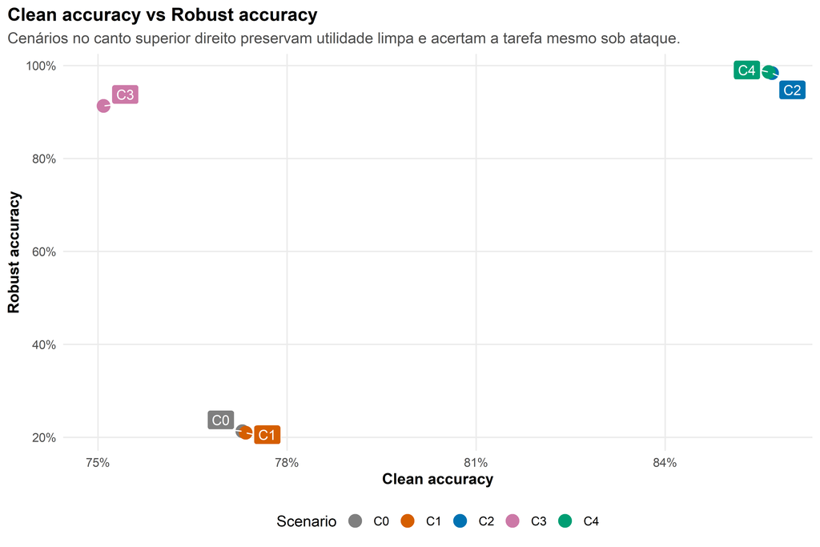

```r
p_clean_vs_robust <- scenario_summary |>
  ggplot(aes(x = clean_accuracy, y = robust_accuracy_all_attacks, color = scenario_short)) +
  geom_segment(
    aes(
      x = pmax(clean_accuracy - clean_accuracy_sd, 0),
      xend = pmin(clean_accuracy + clean_accuracy_sd, 1),
      y = robust_accuracy_all_attacks,
      yend = robust_accuracy_all_attacks
    ),
    alpha = 0.35,
    na.rm = TRUE,
    show.legend = FALSE
  ) +
  geom_errorbar(
    aes(
      ymin = pmax(robust_accuracy_all_attacks - robust_accuracy_all_attacks_sd, 0),
      ymax = pmin(robust_accuracy_all_attacks + robust_accuracy_all_attacks_sd, 1)
    ),
    width = 0.002,
    alpha = 0.35,
    na.rm = TRUE,
    show.legend = FALSE
  ) +
  geom_point(size = 4.5) +
  ggrepel::geom_label_repel(
    aes(label = scenario_short, fill = scenario_short),
    seed = 42,
    min.segment.length = 0,
    box.padding = 0.35,
    color = "white",
    show.legend = FALSE
  ) +
  scale_color_manual(values = scenario_palette, drop = FALSE) +
  scale_fill_manual(values = scenario_palette, drop = FALSE) +
  scale_x_continuous(labels = pct_axis) +
  scale_y_continuous(labels = pct_axis) +
  labs(
    title = "Clean accuracy vs Robust accuracy",
    subtitle = "Cenários no canto superior direito preservam utilidade limpa e acertam a tarefa mesmo sob ataque.",
    x = "Clean accuracy",
    y = "Robust accuracy",
    color = "Scenario"
  ) +
  base_theme()

print(p_clean_vs_robust)
```

```r
save_figure(
  p_clean_vs_robust,
  "02_clean_accuracy_vs_robust_accuracy.png",
  "Figure 2 — Clean accuracy vs Robust accuracy",
  "Scatter plot comparing clean utility and utility under attack."
)
```

# 7 Figura 3 — Utility without attack vs Utility under attack

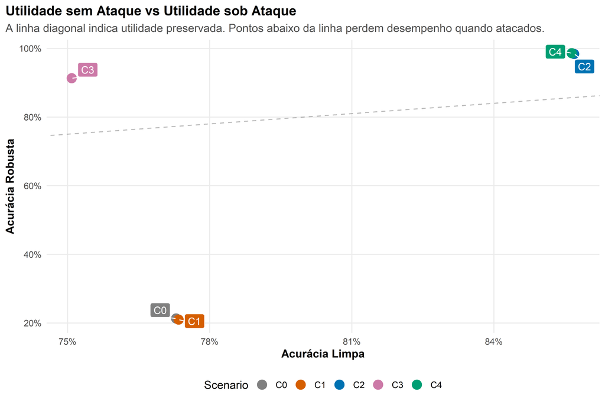

```r
p_utility_clean_vs_attacked <- scenario_summary |>
  ggplot(aes(x = clean_accuracy, y = utility_under_attack_all_attacks, color = scenario_short)) +
  geom_abline(intercept = 0, slope = 1, linetype = "dashed", alpha = 0.45, color = "grey40") +
  geom_point(size = 4.5) +
  ggrepel::geom_label_repel(
    aes(label = scenario_short, fill = scenario_short),
    seed = 42,
    min.segment.length = 0,
    box.padding = 0.35,
    color = "white",
    show.legend = FALSE
  ) +
  scale_color_manual(values = scenario_palette, drop = FALSE) +
  scale_fill_manual(values = scenario_palette, drop = FALSE) +
  scale_x_continuous(labels = pct_axis) +
  scale_y_continuous(labels = pct_axis) +
  labs(
    title = "Utilidade sem Ataque vs Utilidade sob Ataque",
    subtitle = "A linha diagonal indica utilidade preservada. Pontos abaixo da linha perdem desempenho quando atacados.",
    x = "Acurácia Limpa",
    y = "Acurácia Robusta",
    color = "Scenario"
  ) +
  base_theme()

print(p_utility_clean_vs_attacked)
```

```r
save_figure(
  p_utility_clean_vs_attacked,
  "03_utility_without_attack_vs_under_attack.png",
  "Figure 3 — Utility without attack vs Utility under attack",
  "Scatter plot comparing clean accuracy with robust accuracy under attacked inputs."
)
```

# 8 Figura 4 — Seen vs unseen Injection Following Rate

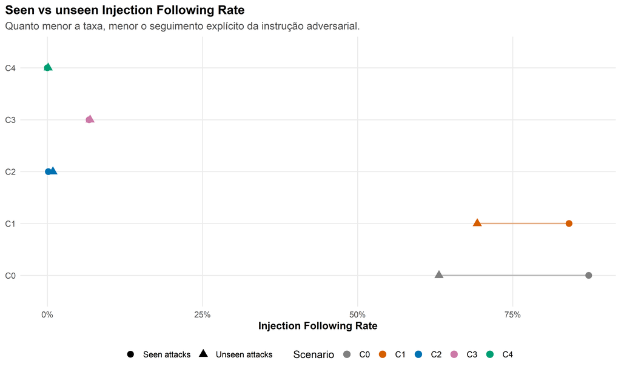

```r
seen_unseen_ifr <- scenario_summary |>
  select(
    scenario_id,
    scenario_short,
    injection_following_rate_seen,
    injection_following_rate_unseen
  ) |>
  pivot_longer(
    cols = c(injection_following_rate_seen, injection_following_rate_unseen),
    names_to = "attack_group",
    values_to = "injection_following_rate"
  ) |>
  mutate(
    attack_group = recode(
      attack_group,
      injection_following_rate_seen = "Seen attacks",
      injection_following_rate_unseen = "Unseen attacks"
    ),
    scenario_short = ordered_scenario_short(as.character(scenario_short))
  )

p_seen_unseen_ifr <- seen_unseen_ifr |>
  ggplot(aes(x = injection_following_rate, y = scenario_short, color = scenario_short)) +
  geom_line(aes(group = scenario_short), linewidth = 0.8, alpha = 0.45, show.legend = FALSE) +
  geom_point(aes(shape = attack_group), size = 3.4) +
  scale_color_manual(values = scenario_palette, drop = FALSE) +
  scale_x_continuous(labels = pct_axis) +
  labs(
    title = "Seen vs unseen Injection Following Rate",
    subtitle = "Quanto menor a taxa, menor o seguimento explícito da instrução adversarial.",
    x = "Injection Following Rate",
    y = NULL,
    color = "Scenario",
    shape = NULL
  ) +
  base_theme()

print(p_seen_unseen_ifr)
```

```r
save_figure(
  p_seen_unseen_ifr,
  "04_seen_vs_unseen_injection_following_rate.png",
  "Figure 4 — Seen vs unseen Injection Following Rate",
  "Dumbbell-style comparison of injection following on seen and unseen attack splits."
)
```

# 9 Figura 5 — Estabilidade entre seeds

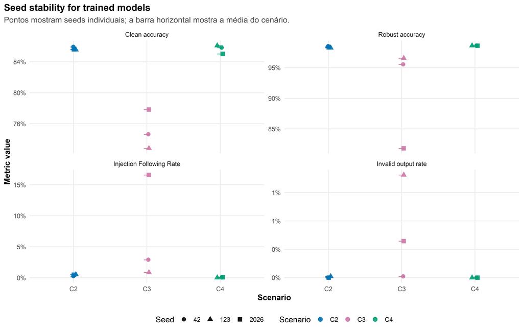

```r
seed_stability_plot_data <- run_level |>
  filter(scenario_id %in% c("c2_struq_sft", "c3_secalign_dpo", "c4_ih_sft")) |>
  select(
    scenario_short,
    seed,
    clean_accuracy,
    robust_accuracy_all_attacks,
    injection_following_rate_all_attacks,
    invalid_output_rate_all_attacks
  ) |>
  pivot_longer(
    cols = c(
      clean_accuracy,
      robust_accuracy_all_attacks,
      injection_following_rate_all_attacks,
      invalid_output_rate_all_attacks
    ),
    names_to = "metric",
    values_to = "value"
  ) |>
  mutate(
    metric_label = case_when(
      metric == "clean_accuracy" ~ "Clean accuracy",
      metric == "robust_accuracy_all_attacks" ~ "Robust accuracy",
      metric == "injection_following_rate_all_attacks" ~ "Injection Following Rate",
      metric == "invalid_output_rate_all_attacks" ~ "Invalid output rate",
      TRUE ~ metric
    ),
    metric_label = factor(
      metric_label,
      levels = c(
        "Clean accuracy",
        "Robust accuracy",
        "Injection Following Rate",
        "Invalid output rate"
      )
    ),
    scenario_short = factor(scenario_short, levels = c("C2", "C3", "C4"))
  )

p_seed_stability <- seed_stability_plot_data |>
  ggplot(aes(x = scenario_short, y = value, color = scenario_short, group = interaction(scenario_short, seed))) +
  geom_point(aes(shape = factor(seed)), size = 2.8, alpha = 0.9, position = position_jitter(width = 0.045, height = 0)) +
  stat_summary(fun = mean, geom = "point", size = 5, shape = 95, show.legend = FALSE) +
  facet_wrap(~ metric_label, ncol = 2, scales = "free_y") +
  scale_color_manual(values = scenario_palette[c("C2", "C3", "C4")], drop = FALSE) +
  scale_y_continuous(labels = pct_axis) +
  labs(
    title = "Seed stability for trained models",
    subtitle = "Pontos mostram seeds individuais; a barra horizontal mostra a média do cenário.",
    x = "Scenario",
    y = "Metric value",
    color = "Scenario",
    shape = "Seed"
  ) +
  base_theme()

print(p_seed_stability)
```

```r
save_figure(
  p_seed_stability,
  "05_seed_stability_trained_models.png",
  "Figure 5 — Seed stability for trained models",
  "Per-seed metric distribution for C2, C3 and C4."
)
```

# 10 Figura 6 — Invalid output rate

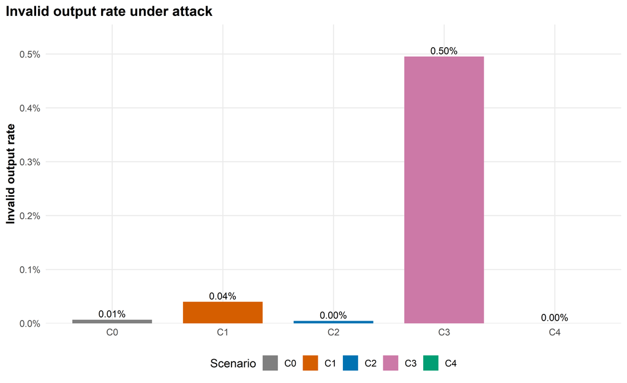

```r
invalid_plot_data <- scenario_summary |>
  mutate(scenario_short = ordered_scenario_short(as.character(scenario_short)))

p_invalid <- invalid_plot_data |>
  ggplot(aes(x = scenario_short, y = invalid_output_rate_all_attacks, fill = scenario_short)) +
  geom_col(width = 0.72) +
  geom_text(
    aes(label = scales::percent(invalid_output_rate_all_attacks, accuracy = 0.01)),
    vjust = -0.35,
    size = 3.5,
    color = "black"
  ) +
  scale_fill_manual(values = scenario_palette, drop = FALSE) +
  scale_y_continuous(labels = pct_axis_small, expand = expansion(mult = c(0, 0.12))) +
  labs(
    title = "Invalid output rate under attack",
    x = NULL,
    y = "Invalid output rate",
    fill = "Scenario"
  ) +
  base_theme()

print(p_invalid)
```

```r
save_figure(
  p_invalid,
  "06_invalid_output_rate_under_attack.png",
  "Figure 6 — Invalid output rate under attack",
  "Bar chart showing invalid output rate for attacked examples."
)
```

# 11 Preparação de dados por tipo de ataque

```r
attack_type_raw <- read_first_existing(c(
  file.path(DESC_DIR, "12_metrics_by_attack_type_recomputed.csv"),
  file.path(DATA_DIR, "metrics", "full", "attack_type_level_metrics.csv"),
  file.path(DATA_DIR, "error_analysis", "full", "tables", "error_rates_by_attack_type.csv")
), required = FALSE)

attack_type_heatmap <- NULL
attack_type_radar <- NULL

if (!is.null(attack_type_raw)) {
  attack_type_data <- add_scenario_info(attack_type_raw)

  attack_type_data$n_weight <- coalesce_col(attack_type_data, c("n_examples", "total"))
  attack_type_data$ifr <- coalesce_col(
    attack_type_data,
    c("injection_following_rate", "targeted_asr", "attack_success_rate", "attack_following_rate", "binary_asv")
  )
  attack_type_data$invalid_rate <- coalesce_col(
    attack_type_data,
    c("invalid_output_rate")
  )
  attack_type_data$robust_rate <- coalesce_col(
    attack_type_data,
    c("robust_accuracy", "correct_rate", "task_success_rate")
  )

  if ("eval_group" %in% names(attack_type_data)) {
    attack_type_data <- attack_type_data |>
      filter(eval_group != "clean")
  } else if ("eval_split" %in% names(attack_type_data)) {
    attack_type_data <- attack_type_data |>
      filter(eval_split != "test_clean")
  }

  attack_type_heatmap <- attack_type_data |>
    filter(!is.na(attack_type), !is.na(ifr)) |>
    group_by(scenario_id, scenario_short, attack_type) |>
    summarise(
      injection_following_rate = weighted_rate(ifr, n_weight),
      invalid_output_rate = weighted_rate(invalid_rate, n_weight),
      robust_accuracy = weighted_rate(robust_rate, n_weight),
      n_examples = sum(n_weight, na.rm = TRUE),
      .groups = "drop"
    ) |>
    sort_scenarios() |>
    mutate(
      scenario_short = ordered_scenario_short(as.character(scenario_short)),
      attack_type_label = stringr::str_replace_all(attack_type, "_", " "),
      attack_type_label = stringr::str_to_title(attack_type_label)
    )

  attack_type_levels <- attack_type_heatmap |>
    group_by(attack_type_label) |>
    summarise(order_value = mean(injection_following_rate, na.rm = TRUE), .groups = "drop") |>
    arrange(desc(order_value)) |>
    pull(attack_type_label)

  attack_type_heatmap <- attack_type_heatmap |>
    mutate(attack_type_label = factor(attack_type_label, levels = attack_type_levels))

  attack_type_radar <- attack_type_heatmap |>
    select(scenario_short, attack_type_label, injection_following_rate, robust_accuracy) |>
    pivot_longer(
      cols = c(injection_following_rate, robust_accuracy),
      names_to = "metric",
      values_to = "value"
    ) |>
    mutate(
      metric_label = case_when(
        metric == "injection_following_rate" ~ "Injection Following Rate",
        metric == "robust_accuracy" ~ "Robust accuracy",
        TRUE ~ metric
      ),
      metric_label = factor(
        metric_label,
        levels = c("Injection Following Rate", "Robust accuracy")
      )
    )
}
```

# 12 Figura 7 — Heatmap por tipo de ataque

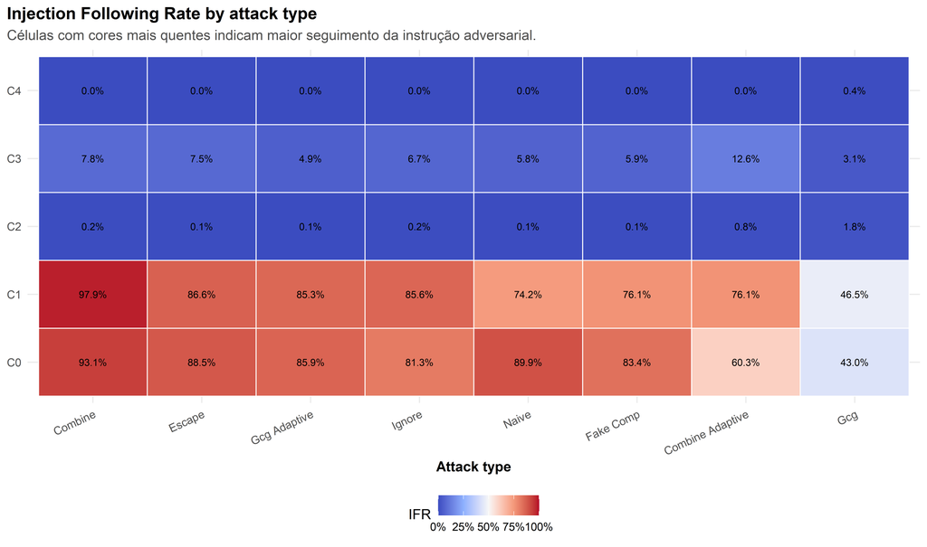

```r
if (is.null(attack_type_heatmap)) {
  cat("Nenhum arquivo de métricas por tipo de ataque foi encontrado. Figura pulada.")
} else {
  p_attack_type_heatmap <- attack_type_heatmap |>
    ggplot(aes(x = attack_type_label, y = scenario_short, fill = injection_following_rate)) +
    geom_tile(color = "white", linewidth = 0.4) +
    geom_text(aes(label = scales::percent(injection_following_rate, accuracy = 0.1)), size = 3) +
    scale_fill_gradientn(
      colours = coolwarm_cols,
      labels = pct_axis,
      name = "IFR",
      limits = c(0, 1)
    ) +
    labs(
      title = "Injection Following Rate by attack type",
      subtitle = "Células com cores mais quentes indicam maior seguimento da instrução adversarial.",
      x = "Attack type",
      y = NULL
    ) +
    base_theme() +
    theme(axis.text.x = element_text(angle = 25, hjust = 1))

  print(p_attack_type_heatmap)

  save_figure(
    p_attack_type_heatmap,
    "07_attack_type_injection_following_heatmap.png",
    "Figure 7 — Injection Following Rate by attack type",
    "Heatmap of injection following rate by scenario and attack type.",
    width = 11,
    height = 6.5
  )

  readr::write_csv(
    attack_type_heatmap,
    file.path(MAIN_TABLES_DIR, "figures_attack_type_ifr_fraction.csv")
  )
}
```

# 13 Figura 8 — Heatmap por tarefa

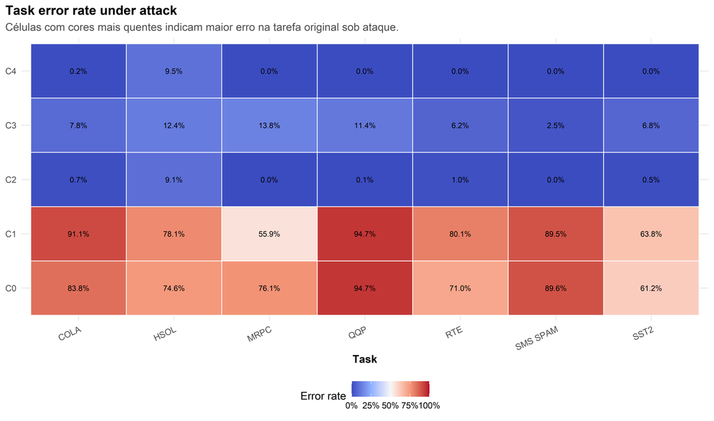

```r
task_raw <- read_first_existing(c(
  file.path(DESC_DIR, "11_metrics_by_task_recomputed.csv"),
  file.path(DATA_DIR, "metrics", "full", "task_level_metrics.csv"),
  file.path(DATA_DIR, "error_analysis", "full", "tables", "error_rates_by_task.csv")
), required = FALSE)

if (is.null(task_raw)) {
  cat("Nenhum arquivo de métricas por tarefa foi encontrado. Figura pulada.")
} else {
  task_data <- add_scenario_info(task_raw)

  task_data$n_weight <- coalesce_col(task_data, c("n_examples", "total"))
  task_data$error_rate_metric <- coalesce_col(task_data, c("error_rate", "untargeted_asr"))
  task_data$robust_metric <- coalesce_col(task_data, c("robust_accuracy", "correct_rate", "task_success_rate"))

  task_data$error_rate_final <- dplyr::coalesce(task_data$error_rate_metric, 1 - task_data$robust_metric)

  if ("eval_group" %in% names(task_data)) {
    task_data <- task_data |>
      filter(eval_group != "clean")
  } else if ("eval_split" %in% names(task_data)) {
    task_data <- task_data |>
      filter(eval_split != "test_clean")
  }

  task_heatmap <- task_data |>
    filter(!is.na(task_name), !is.na(error_rate_final)) |>
    group_by(scenario_id, scenario_short, task_name) |>
    summarise(
      error_rate = weighted_rate(error_rate_final, n_weight),
      n_examples = sum(n_weight, na.rm = TRUE),
      .groups = "drop"
    ) |>
    sort_scenarios() |>
    mutate(
      scenario_short = ordered_scenario_short(as.character(scenario_short)),
      task_name = stringr::str_replace_all(task_name, "_", " "),
      task_name = stringr::str_to_upper(task_name)
    )

  p_task_heatmap <- task_heatmap |>
    ggplot(aes(x = task_name, y = scenario_short, fill = error_rate)) +
    geom_tile(color = "white", linewidth = 0.4) +
    geom_text(aes(label = scales::percent(error_rate, accuracy = 0.1)), size = 3) +
    scale_fill_gradientn(
      colours = coolwarm_cols,
      labels = pct_axis,
      name = "Error rate",
      limits = c(0, 1)
    ) +
    labs(
      title = "Task error rate under attack",
      subtitle = "Células com cores mais quentes indicam maior erro na tarefa original sob ataque.",
      x = "Task",
      y = NULL
    ) +
    base_theme() +
    theme(axis.text.x = element_text(angle = 25, hjust = 1))

  print(p_task_heatmap)

  save_figure(
    p_task_heatmap,
    "08_task_error_rate_under_attack_heatmap.png",
    "Figure 8 — Task error rate under attack",
    "Heatmap of error rate by scenario and task under attacked inputs.",
    width = 11,
    height = 6.5
  )

  readr::write_csv(
    task_heatmap,
    file.path(MAIN_TABLES_DIR, "figures_task_error_rate_fraction.csv")
  )
}
```

# 14 Figura 9 — Taxonomia de falhas sob ataque

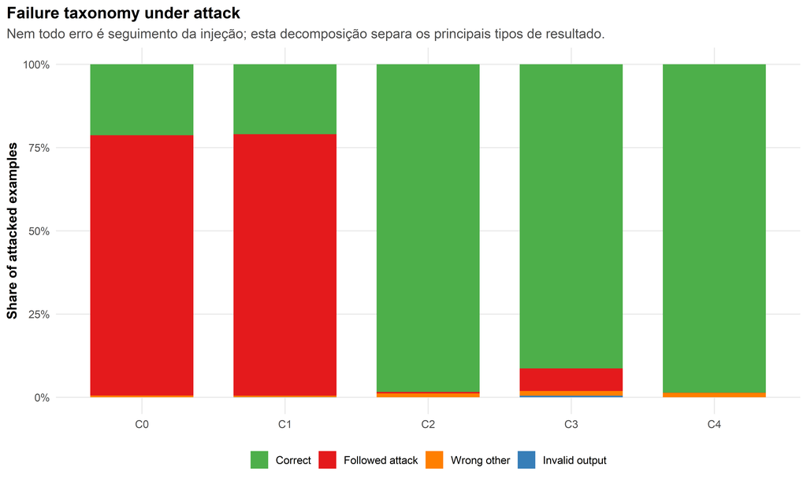

```r
failure_raw <- read_first_existing(c(
  file.path(DESC_DIR, "10_failure_taxonomy_recomputed.csv"),
  file.path(DATA_DIR, "error_analysis", "full", "tables", "failure_taxonomy_by_scenario_seed_split.csv")
), required = FALSE)

if (is.null(failure_raw)) {
  cat("Nenhum arquivo de taxonomia de falhas foi encontrado. Figura pulada.")
} else {
  failure_data <- add_scenario_info(failure_raw)

  if ("eval_group" %in% names(failure_data)) {
    failure_data <- failure_data |>
      filter(eval_group != "clean")
  } else if ("eval_split" %in% names(failure_data)) {
    failure_data <- failure_data |>
      filter(eval_split != "test_clean")
  }

  failure_summary <- failure_data |>
    group_by(scenario_id, scenario_short, failure_type) |>
    summarise(count = sum(count, na.rm = TRUE), .groups = "drop_last") |>
    mutate(rate = count / sum(count, na.rm = TRUE)) |>
    ungroup() |>
    sort_scenarios() |>
    mutate(
      scenario_short = ordered_scenario_short(as.character(scenario_short)),
      failure_type_label = case_when(
        failure_type == "correct" ~ "Correct",
        failure_type == "followed_attack" ~ "Followed attack",
        failure_type == "invalid_output" ~ "Invalid output",
        failure_type == "wrong_other" ~ "Wrong other",
        TRUE ~ failure_type
      ),
      failure_type_label = factor(
        failure_type_label,
        levels = c("Correct", "Followed attack", "Wrong other", "Invalid output")
      )
    )

  failure_fill <- c(
    "Correct" = "#4daf4a",
    "Followed attack" = "#e41a1c",
    "Wrong other" = "#ff7f00",
    "Invalid output" = "#377eb8"
  )

  p_failure_taxonomy <- failure_summary |>
    ggplot(aes(x = scenario_short, y = rate, fill = failure_type_label)) +
    geom_col(width = 0.72) +
    scale_fill_manual(values = failure_fill, drop = FALSE) +
    scale_y_continuous(labels = pct_axis) +
    labs(
      title = "Failure taxonomy under attack",
      subtitle = "Nem todo erro é seguimento da injeção; esta decomposição separa os principais tipos de resultado.",
      x = NULL,
      y = "Share of attacked examples",
      fill = NULL
    ) +
    base_theme()

  print(p_failure_taxonomy)

  save_figure(
    p_failure_taxonomy,
    "09_failure_taxonomy_under_attack.png",
    "Figure 9 — Failure taxonomy under attack",
    "Stacked bar chart decomposing attacked examples into correct, followed attack, wrong other and invalid output."
  )

  readr::write_csv(
    failure_summary,
    file.path(MAIN_TABLES_DIR, "figures_failure_taxonomy_under_attack_fraction.csv")
  )
}
```

# 15 Figura 10 — Gráfico radial por tipo de ataque

```r
if (is.null(attack_type_radar)) {
  cat("Nenhum arquivo de métricas por tipo de ataque foi encontrado. Figura pulada.")
} else {
  radar_levels <- levels(attack_type_heatmap$attack_type_label)
  n_axes <- length(radar_levels)

  radar_plot_data <- attack_type_radar |>
    mutate(
      attack_type_label = factor(attack_type_label, levels = radar_levels),
      axis_id = as.integer(attack_type_label),
      scenario_short = ordered_scenario_short(as.character(scenario_short))
    ) |>
    arrange(metric_label, scenario_short, axis_id) |>
    group_by(metric_label, scenario_short) |>
    group_modify(~ bind_rows(.x, .x |> slice(1) |> mutate(axis_id = n_axes + 1))) |>
    ungroup()

    p_radar_attack_type <- radar_plot_data |>
    ggplot(aes(x = axis_id, y = value, color = scenario_short, group = scenario_short)) +
    geom_hline(yintercept = c(0.25, 0.50, 0.75, 1.00), color = "grey85", linewidth = 0.35) +
    geom_line(linewidth = 1) +
    geom_point(size = 1.8) +
    facet_wrap(~ metric_label, ncol = 2) +
    coord_polar() +
    scale_color_manual(values = scenario_palette, drop = FALSE) +
    scale_x_continuous(
      breaks = seq_len(n_axes),
      labels = radar_levels,
      limits = c(1, n_axes + 1)
    ) +
    scale_y_continuous(
      labels = pct_axis,
      limits = c(0, 1)
    ) +
    labs(
      title = "Comparação de IFR e RA por Tipo de Ataque",
      x = NULL,
      y = NULL,
      color = "Scenario"
    ) +
    base_theme() +
    theme(
      axis.text.y = element_blank(),
      axis.ticks = element_blank(),
      panel.grid.major.x = element_line(color = "grey88", linewidth = 0.3)
    )

  print(p_radar_attack_type)

  save_figure(
    p_radar_attack_type,
    "10_attack_type_radial_comparison.png",
    "Figure 10 — Attack-type radial comparison",
    "Radial chart comparing robust accuracy and injection following rate across attack types.",
    width = 26,
    height = 10
  )
}
```

[figure not shown]

# 16 Figura 11 — Scatterplot por tipo de ataque

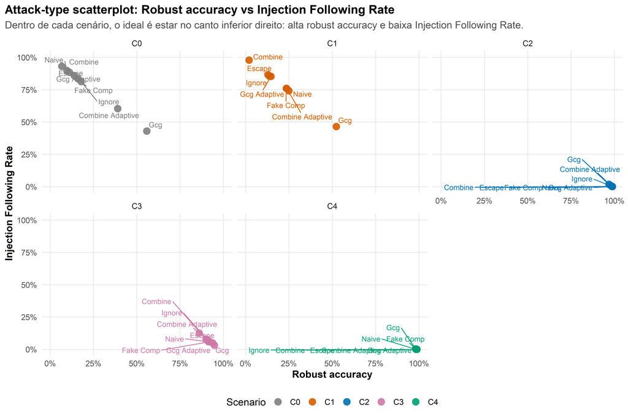

```r
if (is.null(attack_type_heatmap)) {
  cat("Nenhum arquivo de métricas por tipo de ataque foi encontrado. Figura pulada.")
} else {
  p_attack_type_scatter <- attack_type_heatmap |>
    ggplot(
      aes(
        x = robust_accuracy,
        y = injection_following_rate,
        color = scenario_short,
        label = attack_type_label
      )
    ) +
    geom_point(size = 3.6, alpha = 0.9) +
    ggrepel::geom_text_repel(size = 3.1, show.legend = FALSE, seed = 42, max.overlaps = 30) +
    facet_wrap(~ scenario_short) +
    scale_color_manual(values = scenario_palette, drop = FALSE) +
    scale_x_continuous(labels = pct_axis, limits = c(0, 1)) +
    scale_y_continuous(labels = pct_axis, limits = c(0, 1)) +
    labs(
      title = "Attack-type scatterplot: Robust accuracy vs Injection Following Rate",
      subtitle = "Dentro de cada cenário, o ideal é estar no canto inferior direito: alta robust accuracy e baixa Injection Following Rate.",
      x = "Robust accuracy",
      y = "Injection Following Rate",
      color = "Scenario"
    ) +
    base_theme()

  print(p_attack_type_scatter)

  save_figure(
    p_attack_type_scatter,
    "11_attack_type_scatter_robust_vs_ifr.png",
    "Figure 11 — Attack-type scatterplot",
    "Scatterplot comparing robust accuracy and injection following rate across attack types within each scenario.",
    width = 10.5,
    height = 7
  )
}
```

# 17 Painel principal

```r
p_panel_a <- p_clean_vs_ifr + labs(title = "A. Utility vs injection following")
p_panel_b <- p_clean_vs_robust + labs(title = "B. Utility vs robustness")
p_panel_c <- p_seen_unseen_ifr + labs(title = "C. Seen vs unseen IFR")
p_panel_d <- p_invalid + labs(title = "D. Invalid output rate")

p_main_panel <- (p_panel_a | p_panel_b) / (p_panel_c | p_panel_d) +
  plot_annotation(
    title = "RPC-PI main results panel",
    subtitle = "Resumo visual da utilidade limpa, robustez, seguimento da injeção e validade das saídas."
  )

print(p_main_panel)
```

[figure not shown]

```r
save_figure(
  p_main_panel,
  "00_main_results_panel.png",
  "Figure 0 — Main results panel",
  "Combined panel with the four most important result views.",
  width = 12,
  height = 10
)
```

# 18 Índice das figuras geradas

```r
readr::write_csv(
  figure_index,
  file.path(MAIN_TABLES_DIR, "figures_index.csv")
)

figure_index |>
  knitr::kable(
    caption = "Índice das figuras exportadas por este Rmd."
  )
```

Índice das figuras exportadas por este Rmd.

| figure | file | description |
| --- | --- | --- |
| Figure 1 — Clean accuracy vs Injection Following Rate | figures/main/01_clean_accuracy_vs_injection_following_rate.png | Scatter plot showing the utility-security trade-off. |
| Figure 2 — Clean accuracy vs Robust accuracy | figures/main/02_clean_accuracy_vs_robust_accuracy.png | Scatter plot comparing clean utility and utility under attack. |
| Figure 3 — Utility without attack vs Utility under attack | figures/main/03_utility_without_attack_vs_under_attack.png | Scatter plot comparing clean accuracy with robust accuracy under attacked inputs. |
| Figure 4 — Seen vs unseen Injection Following Rate | figures/main/04_seen_vs_unseen_injection_following_rate.png | Dumbbell-style comparison of injection following on seen and unseen attack splits. |
| Figure 5 — Seed stability for trained models | figures/main/05_seed_stability_trained_models.png | Per-seed metric distribution for C2, C3 and C4. |
| Figure 6 — Invalid output rate under attack | figures/main/06_invalid_output_rate_under_attack.png | Bar chart showing invalid output rate for attacked examples. |
| Figure 7 — Injection Following Rate by attack type | figures/main/07_attack_type_injection_following_heatmap.png | Heatmap of injection following rate by scenario and attack type. |
| Figure 8 — Task error rate under attack | figures/main/08_task_error_rate_under_attack_heatmap.png | Heatmap of error rate by scenario and task under attacked inputs. |
| Figure 9 — Failure taxonomy under attack | figures/main/09_failure_taxonomy_under_attack.png | Stacked bar chart decomposing attacked examples into correct, followed attack, wrong other and invalid output. |
| Figure 10 — Attack-type radial comparison | figures/main/10_attack_type_radial_comparison.png | Radial chart comparing robust accuracy and injection following rate across attack types. |
| Figure 11 — Attack-type scatterplot | figures/main/11_attack_type_scatter_robust_vs_ifr.png | Scatterplot comparing robust accuracy and injection following rate across attack types within each scenario. |
| Figure 0 — Main results panel | figures/main/00_main_results_panel.png | Combined panel with the four most important result views. |

# 19 Ordem sugerida no relatório

A ordem sugerida para o relatório/artigo é:

1. `00_main_results_panel.png`, para uma visão geral;
2. `01_clean_accuracy_vs_injection_following_rate.png`, como gráfico principal de trade-off;
3. `02_clean_accuracy_vs_robust_accuracy.png`, para destacar robustez;
4. `04_seen_vs_unseen_injection_following_rate.png`, para discutir generalização;
5. `07_attack_type_injection_following_heatmap.png`, para padrões por tipo de ataque;
6. `10_attack_type_radial_comparison.png`, como visual complementar inspirado no exemplo radial;
7. `11_attack_type_scatter_robust_vs_ifr.png`, para um trade-off por tipo de ataque dentro de cada cenário.